# Practical Machine Learning -Assignment

Philipp B.

2021-01-03

# Overview

In this assignment, weight lifting data gathered from fitness and health devices is used to predict the *classe* parameter, quantifying the quality of the workout.

The WLE data was provided by Velloso, E.; Bulling, A.; Gellersen, H.; Ugulino, W.; Fuks, H. (http://web.archive.org/web/20161224072740/http:/groupware.les.inf.puc-rio.br/har.; see also: http://groupware.les.inf.puc-rio.br/har#ixzz3xsbS5bVX)

# Preparation

```r
library(dplyr, warn.conflicts = F)
library(tidyr, warn.conflicts = F)
library(ggplot2, warn.conflicts = F)
library(ggridges, warn.conflicts = F)
library(lattice, warn.conflicts = F)
library(caret, warn.conflicts = F)
library(doParallel, warn.conflicts = F)

set.seed(1337)

# read data
if (!exists("training"))
    training <- read.csv(url("https://d396qusza40orc.cloudfront.net/predmachlearn/pml-training.csv"))

if (!exists("testing"))
    testing  <- read.csv(url("https://d396qusza40orc.cloudfront.net/predmachlearn/pml-testing.csv"))
```

After loading the data, some data cleaning and preparation is done. Assuming the *classe* outcome is not depending on time, i.e. it shows no time trend, all time-related columns are excluded for further analysis. Furthermore, all factor variables are reclassified as such.

In the next step, all zero or near-zero columns are removed. Following that, information redundancy in the dataset is reduced by removing highly correlated columns.

```r
# clean column classes
training.char <- training %>% select(which(sapply(., class) =="character"),
                                     -c(user_name, new_window, classe, cvtd_timestamp))
testing.char  <- testing  %>% select(which(sapply(., class) =="character"),
                                     -c(user_name, new_window, cvtd_timestamp))

for (i in names(training.char)) training[, i] <- as.numeric(training[, i])
for (i in names(testing.char)) testing[, i] <- as.numeric(testing[, i])

training$classe <- as.factor(training$classe)

# removing near zero and zero columns
training <- training %>%
    select(-nearZeroVar(.), user_name, classe)

# removing highly correlated columns and columns related to time
training.highcor <- training %>%
    select_if(is.numeric) %>%
    select_if(sapply(., FUN=function(x) sum(is.na(x))) == 0) %>%
    cor() %>%
    findCorrelation(., names=T, exact = T)
training <- training %>%
    select(-training.highcor, -c(X, raw_timestamp_part_1, raw_timestamp_part_2,
                                 cvtd_timestamp))

# removing NA columns
training <-training %>%
    select_if(sapply(., FUN=function(x) sum(is.na(x))) == 0)

# sub-split training set into train and test
inTrain  <- createDataPartition(training$classe, p = 0.6, list = F)
subTrain <- training[inTrain, ]
subTest  <- training[-inTrain, ]
```

All columns containig lots of missing values are removed before the *training* dataset is split into the actual training set, called *subTrain*, and a testing dataset for estimating the out of sample error, called *subTest*.

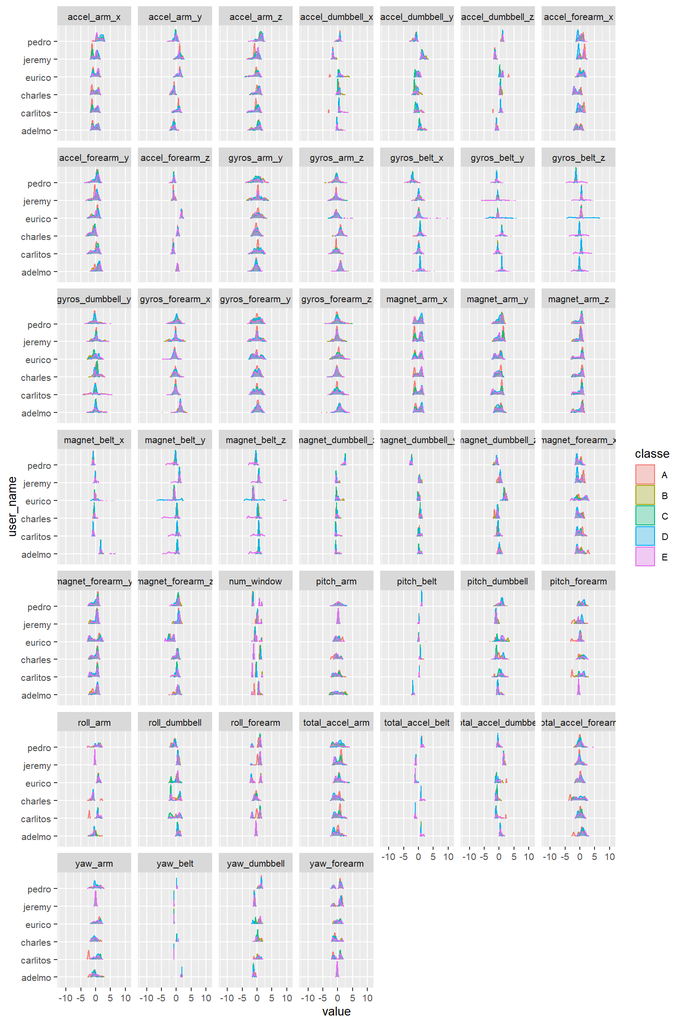

```r
# exploratory analysis
subTrain %>%
    predict(preProcess(., method = c("scale", "center")), .) %>%
    gather(key = "param", value = "value", -c(user_name, classe)) %>%
    ggplot(., aes(x = value, y = user_name, fill = classe, col = classe)) +
        geom_density_ridges(scale = 0.9, alpha = 0.3, rel_min_height=0.005) +
        facet_wrap(~ param) +
        theme(text = element_text(size=10))
```

# Model training and prediction

```r
# preparing for parallel computing
cl <- makePSOCKcluster(detectCores(logical = F))
registerDoParallel(cl)

# training
m.pda   <- train(classe~., data = subTrain, method = "pda", preProcess = c("center", "scale"), trControl = trainControl(method = "cv", classProbs=TRUE,savePredictions=TRUE,allowParallel=TRUE, number = 10))
m.nb <- train(classe~., data = subTrain, method = "naive_bayes", preProcess = c("center", "scale"), trControl = trainControl(method = "cv", classProbs=TRUE,savePredictions=TRUE,allowParallel=TRUE, number = 10))
m.gbm   <- train(classe~., data = subTrain, method = "gbm", verbose = F, preProcess = c("center", "scale"), trControl = trainControl(method = "cv", classProbs=TRUE,savePredictions=TRUE,allowParallel=TRUE, number = 10))
m.rf    <- train(classe~., data = subTrain, method = "rf", preProcess = c("center", "scale"), trControl = trainControl(method = "cv", classProbs=TRUE,savePredictions=TRUE,allowParallel=TRUE, number = 10))
stopCluster(cl)


# estimating out of sample error via validation set subTest
p.pda   <- predict(m.pda, newdata = subTest)
p.nb    <- predict(m.nb, newdata = subTest)
p.gbm   <- predict(m.gbm, newdata = subTest)
p.rf    <- predict(m.rf, newdata = subTest)


a.nb    <- confusionMatrix(p.nb, subTest$classe)
a.pda   <- confusionMatrix(p.pda, subTest$classe)
a.gbm   <- confusionMatrix(p.gbm, subTest$classe)
a.rf    <- confusionMatrix(p.rf, subTest$classe)

model.accuracy <- data.frame(nb = a.nb$overall["Accuracy"],
                             pda = a.pda$overall["Accuracy"],
                             gbm = a.gbm$overall["Accuracy"],
                             rf = a.rf$overall["Accuracy"])

# prediction with testing set
pred <- data.frame(X = testing$X, user_name = testing$user_name,
                   nb = predict(m.nb, newdata = testing),
                   pda = predict(m.pda, newdata = testing),
                   gbm = predict(m.gbm, newdata = testing),
                   rf = predict(m.rf, newdata = testing))

as.data.frame(t(rbind(round(model.accuracy, digit = 4) , pred[,3:6])))
```

```
##     Accuracy 1 2 3 4 5 6 7 8 9 10 11 12 13 14 15 16 17 18 19 20
## nb    0.7634 C A A A A C D C A  A  A  A  B  A  E  B  A  B  D  B
## pda   0.7024 B A B A A C D D A  A  D  A  B  A  E  A  A  B  B  B
## gbm   0.9885 B A B A A E D B A  A  B  C  B  A  E  E  A  B  B  B
## rf    0.9975 B A B A A E D B A  A  B  C  B  A  E  E  A  B  B  B
```

As seen in output table, the random forest method is the most accurate with the lowest out of sample error of $1 - Accuracy = 0.25 \%$. Hence, for final prediction the outcome of the random forest prediction is recommended.